# Exploratory Data Analysis

> Now that the dataframe is relatively clean, we are ready to explore and analyze the dataset of 3805 movies by answering to the questions already asked.

### Question 1: What kinds of properties are associated with most and less successful movies?

To answer to this question, i will first calculate the financial benefit realized by each movie, by substracting the budget adjusted (accounting for inflation overtime) from the revenue adjusted. We say that there is a profit when revenue generated from a movie exceeds the expenses, costs, and taxes involved in sustaining the activity in question and vice versa for losses.

```python
import pandas as pd
import numpy as np
import matplotlib.pyplot as plt
import seaborn as sns

%matplotlib inline
```

```python
df = pd.read_csv('tmdb-movies.csv')
df
```

|  | id | popularity | original_title | cast | director | runtime | genres | production_companies | release_date | vote_count | vote_average | release_year | budget_adj | revenue_adj |
| --- | --- | --- | --- | --- | --- | --- | --- | --- | --- | --- | --- | --- | --- | --- |
| 0 | 135397 | 32.985763 | Jurassic World | Chris Pratt\|Bryce Dallas Howard\|Irrfan Khan\|Vi... | Colin Trevorrow | 124 | Action\|Adventure\|Science Fiction\|Thriller | Universal Studios\|Amblin Entertainment\|Legenda... | 2015-06-09 | 5562 | 6.5 | 2015 | 1.379999e+08 | 1.392446e+09 |
| 1 | 76341 | 28.419936 | Mad Max: Fury Road | Tom Hardy\|Charlize Theron\|Hugh Keays-Byrne\|Nic... | George Miller | 120 | Action\|Adventure\|Science Fiction\|Thriller | Village Roadshow Pictures\|Kennedy Miller Produ... | 2015-05-13 | 6185 | 7.1 | 2015 | 1.379999e+08 | 3.481613e+08 |
| 2 | 262500 | 13.112507 | Insurgent | Shailene Woodley\|Theo James\|Kate Winslet\|Ansel... | Robert Schwentke | 119 | Adventure\|Science Fiction\|Thriller | Summit Entertainment\|Mandeville Films\|Red Wago... | 2015-03-18 | 2480 | 6.3 | 2015 | 1.012000e+08 | 2.716190e+08 |
| 3 | 140607 | 11.173104 | Star Wars: The Force Awakens | Harrison Ford\|Mark Hamill\|Carrie Fisher\|Adam D... | J.J. Abrams | 136 | Action\|Adventure\|Science Fiction\|Fantasy | Lucasfilm\|Truenorth Productions\|Bad Robot | 2015-12-15 | 5292 | 7.5 | 2015 | 1.839999e+08 | 1.902723e+09 |
| 4 | 168259 | 9.335014 | Furious 7 | Vin Diesel\|Paul Walker\|Jason Statham\|Michelle ... | James Wan | 137 | Action\|Crime\|Thriller | Universal Pictures\|Original Film\|Media Rights ... | 2015-04-01 | 2947 | 7.3 | 2015 | 1.747999e+08 | 1.385749e+09 |
| ... | ... | ... | ... | ... | ... | ... | ... | ... | ... | ... | ... | ... | ... | ... |
| 3800 | 396 | 0.670274 | Who's Afraid of Virginia Woolf? | Elizabeth Taylor\|Richard Burton\|George Segal\|S... | Mike Nichols | 131 | Drama | Chenault Productions | 2066-06-21 | 74 | 7.5 | 1966 | 5.038511e+07 | 2.266436e+08 |
| 3801 | 5780 | 0.402730 | Torn Curtain | Paul Newman\|Julie Andrews\|Lila Kedrova\|HansjÃ¶... | Alfred Hitchcock | 128 | Mystery\|Thriller | Universal Pictures | 2066-07-13 | 46 | 6.3 | 1966 | 2.015404e+07 | 8.733419e+07 |
| 3802 | 6644 | 0.395668 | El Dorado | John Wayne\|Robert Mitchum\|James Caan\|Charlene ... | Howard Hawks | 120 | Action\|Western | Paramount Pictures\|Laurel Productions | 2066-12-17 | 36 | 6.9 | 1966 | 3.125892e+07 | 4.030809e+07 |
| 3803 | 5923 | 0.299911 | The Sand Pebbles | Steve McQueen\|Richard Attenborough\|Richard Cre... | Robert Wise | 182 | Action\|Adventure\|Drama\|War\|Romance | Twentieth Century Fox Film Corporation\|Solar P... | 2066-12-20 | 28 | 7.0 | 1966 | 8.061618e+07 | 1.343603e+08 |
| 3804 | 2161 | 0.207257 | Fantastic Voyage | Stephen Boyd\|Raquel Welch\|Edmond O'Brien\|Donal... | Richard Fleischer | 100 | Adventure\|Science Fiction | Twentieth Century Fox Film Corporation | 2066-08-24 | 42 | 6.7 | 1966 | 3.436265e+07 | 8.061618e+07 |

3805 rows × 14 columns

```python
df['profit'] = df['revenue_adj'] - df['budget_adj']
```

```python
def min_max(x):
    highest = df[x].idxmax()
    highest_details = pd.DataFrame(df.loc[highest])

    lowest = df[x].idxmin()
    lowest_details = pd.DataFrame(df.loc[lowest])

    print('Movie which has highest '+x+' : ', df['original_title'][highest])
    print('Movie which has lowest '+x+' : ', df['original_title'][lowest])

    return pd.concat([highest_details, lowest_details], axis=1)
```

#### *1. Which Movie had the highest or lowest profit?*

```python
min_max('profit')
```

```
Movie which has highest profit :  Star Wars
Movie which has lowest profit :  The Warrior's Way
```

|  | 325 | 678 |
| --- | --- | --- |
| id | 11 | 46528 |
| popularity | 12.037933 | 0.25054 |
| original_title | Star Wars | The Warrior's Way |
| cast | Mark Hamill\|Harrison Ford\|Carrie Fisher\|Peter ... | Kate Bosworth\|Jang Dong-gun\|Geoffrey Rush\|Dann... |
| director | George Lucas | Sngmoo Lee |
| runtime | 121 | 100 |
| genres | Adventure\|Action\|Science Fiction | Adventure\|Fantasy\|Action\|Western\|Thriller |
| production_companies | Lucasfilm\|Twentieth Century Fox Film Corporation | Boram Entertainment Inc. |
| release_date | 1977-03-20 | 2010-12-02 |
| vote_count | 4428 | 74 |
| vote_average | 7.9 | 6.4 |
| release_year | 1977 | 2010 |
| budget_adj | 39575591.358274 | 425000000.0 |
| revenue_adj | 2789712242.27745 | 11087569.0 |
| profit | 2750136650.919176 | -413912431.0 |

According to our sample, **the first column** shows the movie with the **highest profit** and **the second column** shows the movie with the **lowest profit**.

#### *2. Which year the movie industry made the highest profit?*

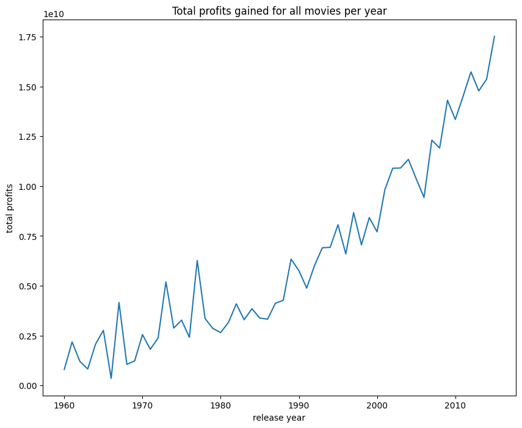

```
The movie industry made the highest profit in 2015 .
```

```python
profit_peryear = df.groupby('release_year')['profit'].sum()

ax = profit_peryear.plot(stacked=True, figsize=(10,8));
ax.set(xlabel='release year', ylabel='total profits', title = 'Total profits gained for all movies per year')
plt.show()

max_profit= profit_peryear.idxmax()

print('The movie industry made the highest profit in', max_profit,'.')
```

#### *3. Which month the movie industry made the highest profit?*

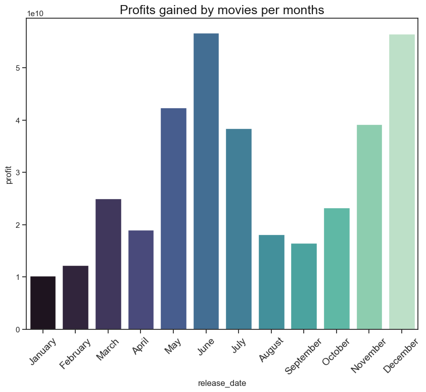

```python
df['release_date'] = pd.to_datetime(df['release_date'], errors='coerce')
releasedate_index = df.set_index('release_date')
groupby_index = releasedate_index.groupby([(releasedate_index.index.month)])

profit_permonth = groupby_index['profit'].sum()
profit_permonth = pd.DataFrame(profit_permonth)

sns.set(rc={'figure.figsize':(10,8)}, style="ticks")

profit_permonth_bar = sns.barplot(
    x=profit_permonth.index,
    y=profit_permonth['profit'],
    data=profit_permonth,
    palette="mako"
)

profit_permonth_bar.axes.set_title('Profits gained by movies per months', color="k", fontsize = 18)

month_list = ['January', 'February', 'March', 'April', 'May', 'June', 'July', 'August', 'September', 'October', 'November', 'December']

profit_permonth_bar.set_xticks(range(0, 12))
profit_permonth_bar.set_xticklabels(month_list, rotation=45, size=14)
plt.show()
```

We can say that **June** and **December** are the months when movies have gained the highest profits. These findings show the effect of holidays and festivities on the movie profitability.

#### *4. Do popular movies get higher profit?*

```
Correlation between Profit and Popularity :  0.5151251162014825
```

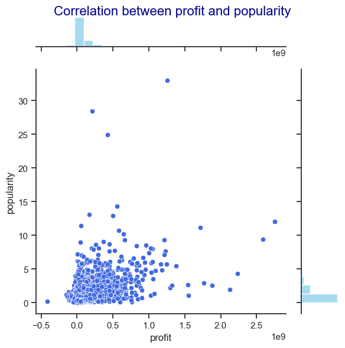

```python
fig1 = sns.jointplot(
    x="profit",
    y="popularity",
    kind="scatter",
    data=df,
    color="royalblue",
    marginal_kws=dict(bins=25, fill=True, color="skyblue")
)

fig1.fig.suptitle('Correlation between profit and popularity', fontsize=16, color="darkblue")
fig1.fig.tight_layout()
fig1.fig.subplots_adjust(top=0.95)

data_corr = df.corr(numeric_only=True)
print("Correlation between Profit and Popularity : ", data_corr.loc['profit', 'popularity'])
```

The correlation has been used to test statistical relationships between profit and popularity. The coefficient is 0.51 so that we can conclude that there is a moderate and positive relationship between the two variables. In other terms, **popular movies could get higher profit**. But to further justify this finding, causality tests should be conducted.

#### *5. What were the most or least expensive movies?*

```python
min_max('budget_adj')
```

```
Movie which has highest budget_adj :  The Warrior's Way
Movie which has lowest budget_adj :  Love, Wedding, Marriage
```

|  | 678 | 1237 |
| --- | --- | --- |
| id | 46528 | 59296 |
| popularity | 0.25054 | 0.52043 |
| original_title | The Warrior's Way | Love, Wedding, Marriage |
| cast | Kate Bosworth\|Jang Dong-gun\|Geoffrey Rush\|Dann... | Mandy Moore\|Kellan Lutz\|Jessica Szohr\|Autumn F... |
| director | Sngmoo Lee | Dermot Mulroney |
| runtime | 100 | 90 |
| genres | Adventure\|Fantasy\|Action\|Western\|Thriller | Comedy\|Romance |
| production_companies | Boram Entertainment Inc. | 120dB Films\|Scion Films\|Voodoo Production Serv... |
| release_date | 2010-12-02 00:00:00 | 2011-06-03 00:00:00 |
| vote_count | 74 | 55 |
| vote_average | 6.4 | 5.3 |
| release_year | 2010 | 2011 |
| budget_adj | 425000000.0 | 0.969398 |
| revenue_adj | 11087569.0 | 1335.830503 |
| profit | -413912431.0 | 1334.861105 |

**The first column** shows the movie with **the highest budget(adjusted)** and **the second column** shows the movie with **the lowest budget**.

- Unfortunatly, the **Warrior's way** which is the less profitable movie has the highest budget in all and very low popularity, spending over $425 million dollars.
- And the least expensive movie in this dataset is **The Love, Wedding, Marriage**, released in 2011. And the surprise is that the profit realized is approximatively equale to the revenue.

#### *6. What is the statistical relationship between budget and profit?*

```
Correlation between Profit and Budget :  0.40179696213602184
```

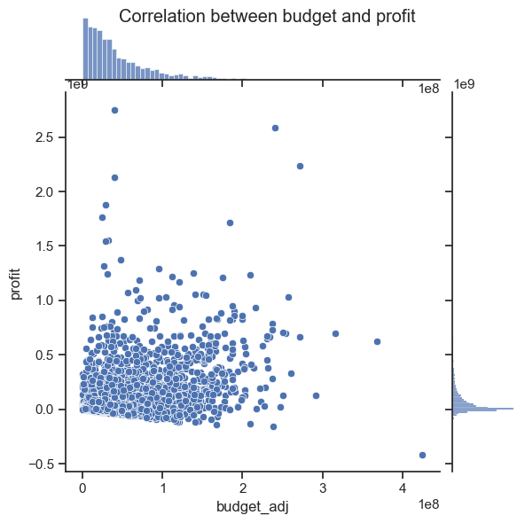

```python
fig2 = sns.jointplot(data = df, x = 'budget_adj', y = 'profit', kind = 'scatter')
fig2.fig.suptitle('Correlation between budget and profit');
print("Correlation between Profit and Budget : ",data_corr.loc['profit','budget_adj'])
```

The correlation coefficient between profit and budget is **0.40**. This indicates a moderate **positive relationship** between the two variables. In other words, as the budget increases, profit tends to increase as well. However, since the value is not very high, the relationship is not strong — meaning other factors beyond budget also play an important role in determining profit.

#### *7. Do movies with highest budget get highest rating?*

```
Correlation between Vote Rating and Budget :  0.0357983183687053
```

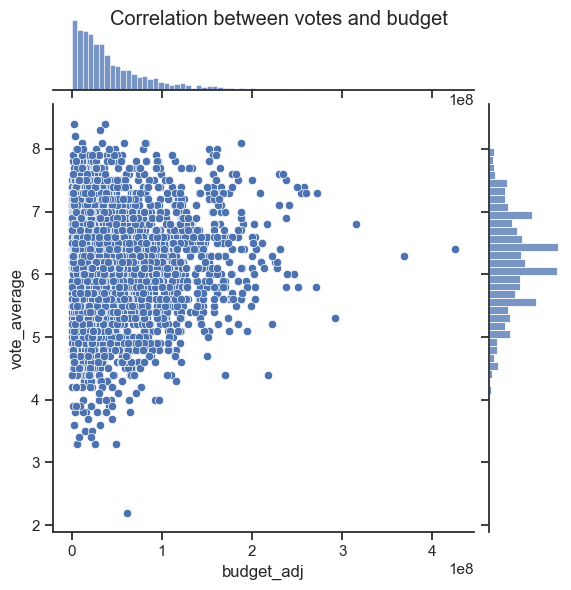

```python
fig3 = sns.jointplot(data = df, x = 'budget_adj', y = 'vote_average', kind = 'scatter')
fig3.fig.suptitle('Correlation between votes and budget');
print("Correlation between Vote Rating and Budget : ",data_corr.loc['vote_average','budget_adj'])
```

The correlation coefficient between vote rating and budget is **0.036**. This indicates a **very weak positive relationship** between the two variables. In other words, the budget of a movie has almost no influence on its audience rating, suggesting that other factors—such as story, acting, or marketing—play a much bigger role in determining how viewers rate a movie.”

#### *8. Which Movie had the highest or lowest revenue?*

```python
min_max('revenue_adj')
```

```
Movie which has highest revenue_adj :  Avatar
Movie which has lowest revenue_adj :  Shattered Glass
```

|  | 344 | 1711 |
| --- | --- | --- |
| id | 19995 | 13537 |
| popularity | 9.432768 | 0.462609 |
| original_title | Avatar | Shattered Glass |
| cast | Sam Worthington\|Zoe Saldana\|Sigourney Weaver\|S... | Hayden Christensen\|Peter Sarsgaard\|ChloÃ« Sevi... |
| director | James Cameron | Billy Ray |
| runtime | 162 | 94 |
| genres | Action\|Adventure\|Fantasy\|Science Fiction | Drama\|History |
| production_companies | Ingenious Film Partners\|Twentieth Century Fox ... | Lions Gate Films\|Cruise/Wagner Productions\|Bau... |
| release_date | 2009-12-10 00:00:00 | 2003-11-14 00:00:00 |
| vote_count | 8458 | 46 |
| vote_average | 7.1 | 6.4 |
| release_year | 2009 | 2003 |
| budget_adj | 240886902.887613 | 7112115.868695 |
| revenue_adj | 2827123750.41189 | 2.370705 |
| profit | 2586236847.524277 | -7112113.49799 |

**The first column** shows **the highest revenue** made by a movie and **the second** one shows the movie with **the lowest revenue**.

#### *9. Is there any statistical relationship between revenue and profit/ revenue and budget?*

```
Correlation between Revenue and Budget :  0.5679827933798446
Correlation between Revenue and profit :  0.9818955693291231
```

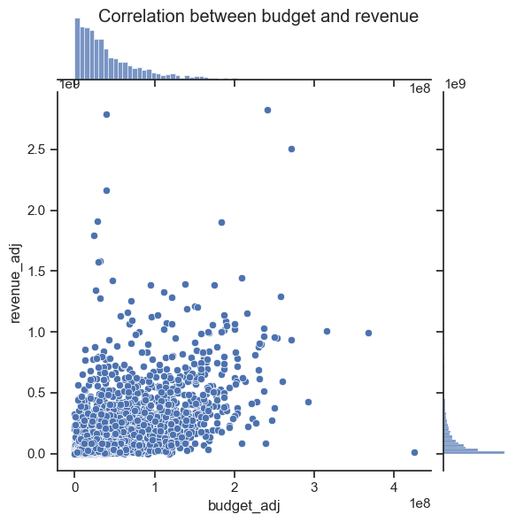

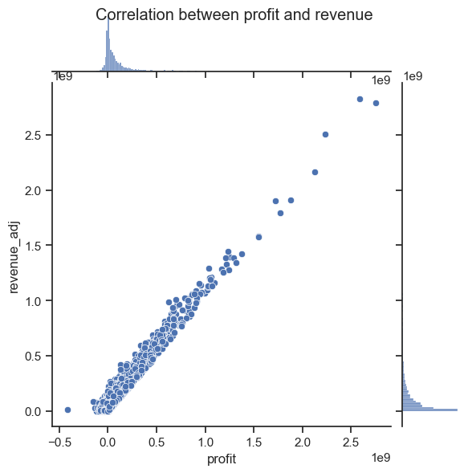

```python
fig4 = sns.jointplot(x = "budget_adj", y = "revenue_adj", kind = "scatter", data = df)
fig4.fig.suptitle('Correlation between budget and revenue');

fig5 = sns.jointplot(x = "profit", y = "revenue_adj", kind = "scatter", data = df)
fig5.fig.suptitle('Correlation between profit and revenue');

print("Correlation between Revenue and Budget : ",data_corr.loc['revenue_adj','budget_adj'])
print("Correlation between Revenue and profit : ",data_corr.loc['revenue_adj','profit'])
```

#### *10. What is the movie length most liked by the audience?*

```
Rutime most liked by audience 169 minutes.
```

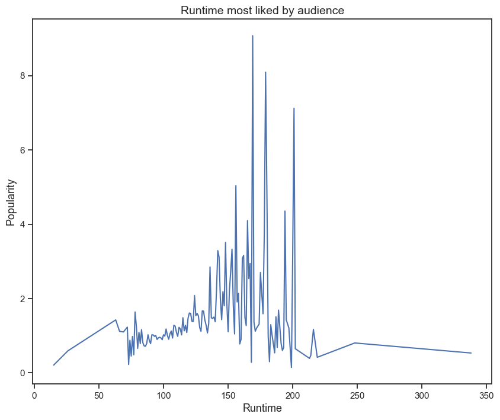

```python
run_pop=df.groupby('runtime')['popularity'].mean()
run_pop.plot(figsize = (10,8))
#title
plt.title("Runtime most liked by audience",fontsize=14)
plt.xlabel('Runtime',fontsize = 13)
plt.ylabel('Popularity',fontsize = 13)
#max_value
max_run= run_pop.idxmax()

print('Rutime most liked by audience', max_run, 'minutes.')
```

#### *11. Which Movie is high or less rated?*

```python
min_max('vote_average')
```

```
Movie which has highest vote_average :  The Shawshank Redemption
Movie which has lowest vote_average :  Foodfight!
```

|  | 1408 | 1623 |
| --- | --- | --- |
| id | 278 | 116977 |
| popularity | 7.192039 | 0.111351 |
| original_title | The Shawshank Redemption | Foodfight! |
| cast | Tim Robbins\|Morgan Freeman\|Bob Gunton\|William ... | Charlie Sheen\|Wayne Brady\|Hilary Duff\|Eva Long... |
| director | Frank Darabont | Lawrence Kasanoff |
| runtime | 142 | 87 |
| genres | Drama\|Crime | Animation\|Action\|Comedy\|Family |
| production_companies | Castle Rock Entertainment | Threshold Entertainment\|Lions Gate Family Ente... |
| release_date | 1994-09-10 00:00:00 | 2012-06-15 00:00:00 |
| vote_count | 5754 | 12 |
| vote_average | 8.4 | 2.2 |
| release_year | 1994 | 2012 |
| budget_adj | 36777789.039954 | 61733378.287896 |
| revenue_adj | 41693462.718576 | 70001.852001 |
| profit | 4915673.678622 | -61663376.435895 |

As we can see, **"The Shawshank Redemption"** released in 1994 and directed by Frank Darabont, has the maximum rating (8.4), while **"Foodfight"** released in 2012 and directed by Lawrence Kasanoff, has the lowestratings (2.2).

#### *12. Do high rated movies get higher profit?*

```
Correlation between Profit and Votes :  0.2901953006770087
```

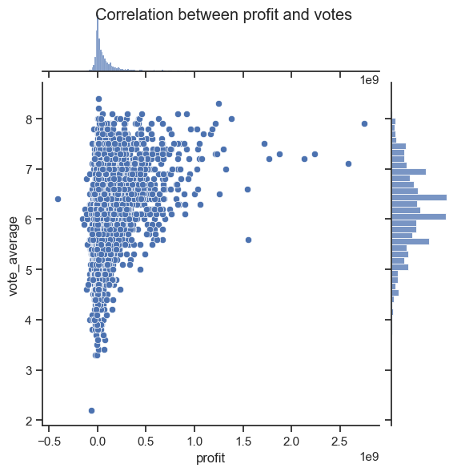

```python
fig6 = sns.jointplot(x = "profit", y = "vote_average", kind = "scatter", data = df)
fig6.fig.suptitle('Correlation between profit and votes');

print("Correlation between Profit and Votes : ",data_corr.loc['profit','vote_average'])
```

### Question 2 :What are the Top 10 movies according to different features (Profit, budget, revenue, popularity, votes)?

```python
Top_revenue = df[["original_title", "revenue_adj"]]
Top_budget = df[['original_title','budget_adj']]
Top_profit = df[["original_title", "profit"]]
Top_popularity = df[['original_title','popularity']]
```

#### *1. Top 10 most profitable movies*

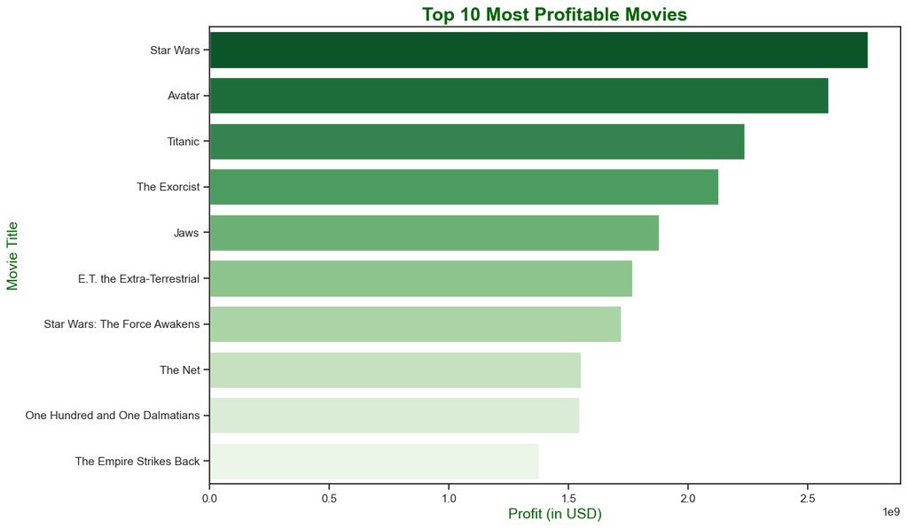

```python
top10_profit = Top_profit.sort_values(by="profit", ascending=False).head(10)

sns.set(style="ticks", rc={'figure.figsize':(12,8)})
bar_plot = sns.barplot(
    x="profit",
    y="original_title",
    data=top10_profit,
    palette="Greens_r"
)

bar_plot.set_title("Top 10 Most Profitable Movies", fontsize=18, color="darkgreen", weight="bold")
bar_plot.set_xlabel("Profit (in USD)", fontsize=14, color="darkgreen")
bar_plot.set_ylabel("Movie Title", fontsize=14, color="darkgreen")

plt.show()
```

#### *2. Top 10 movies based on gained revenue*

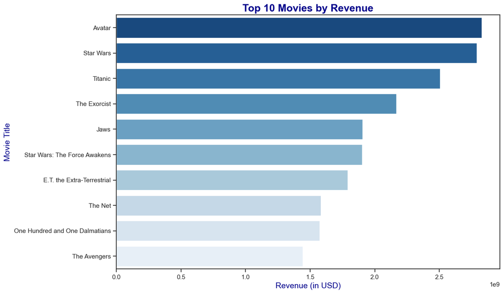

```python
top10_revenue = Top_revenue.sort_values(by="revenue_adj", ascending=False).head(10)

sns.set(style="ticks", rc={'figure.figsize':(12,8)})
bar_plot = sns.barplot(
    x="revenue_adj",
    y="original_title",
    data=top10_revenue,
    palette="Blues_r"
)

bar_plot.set_title("Top 10 Movies by Revenue", fontsize=18, color="darkblue", weight="bold")
bar_plot.set_xlabel("Revenue (in USD)", fontsize=14, color="darkblue")
bar_plot.set_ylabel("Movie Title", fontsize=14, color="darkblue")

plt.show()
```

#### *3. Top 10 most expensive movies*

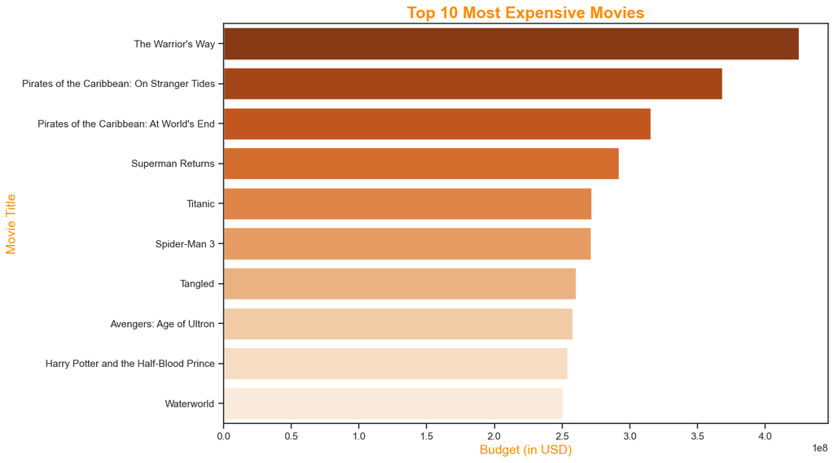

```python
top10_budget = Top_budget.sort_values(by="budget_adj", ascending=False).head(10)

sns.set(style="ticks", rc={'figure.figsize':(12,8)})
bar_plot = sns.barplot(
    x="budget_adj",
    y="original_title",
    data=top10_budget,
    palette="Oranges_r"
)

bar_plot.set_title("Top 10 Most Expensive Movies", fontsize=18, color="darkorange", weight="bold")
bar_plot.set_xlabel("Budget (in USD)", fontsize=14, color="darkorange")
bar_plot.set_ylabel("Movie Title", fontsize=14, color="darkorange")

plt.show()
```

#### *4. Top 10 most popular movies*

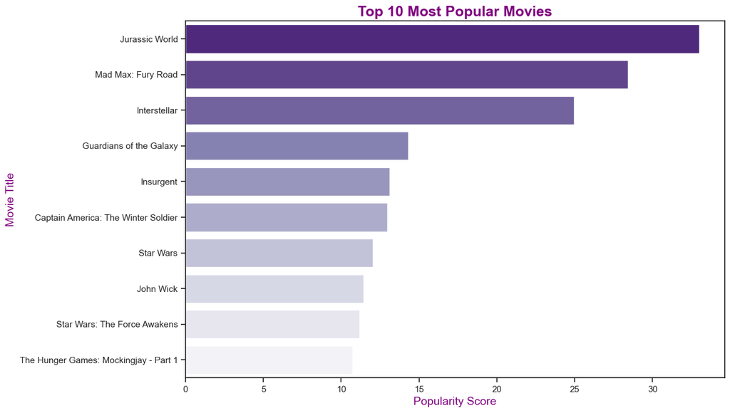

```python
top10_popularity = Top_popularity.sort_values(by="popularity", ascending=False).head(10)

sns.set(style="ticks", rc={'figure.figsize':(12,8)})
bar_plot = sns.barplot(
    x="popularity",
    y="original_title",
    data=top10_popularity,
    palette="Purples_r"
)

bar_plot.set_title("Top 10 Most Popular Movies", fontsize=18, color="purple", weight="bold")
bar_plot.set_xlabel("Popularity Score", fontsize=14, color="purple")
bar_plot.set_ylabel("Movie Title", fontsize=14, color="purple")

plt.show()
```

### Question 3: Which genres are most popular and profitable, overall and overtime?

#### *1. Number of movies produced per genre*

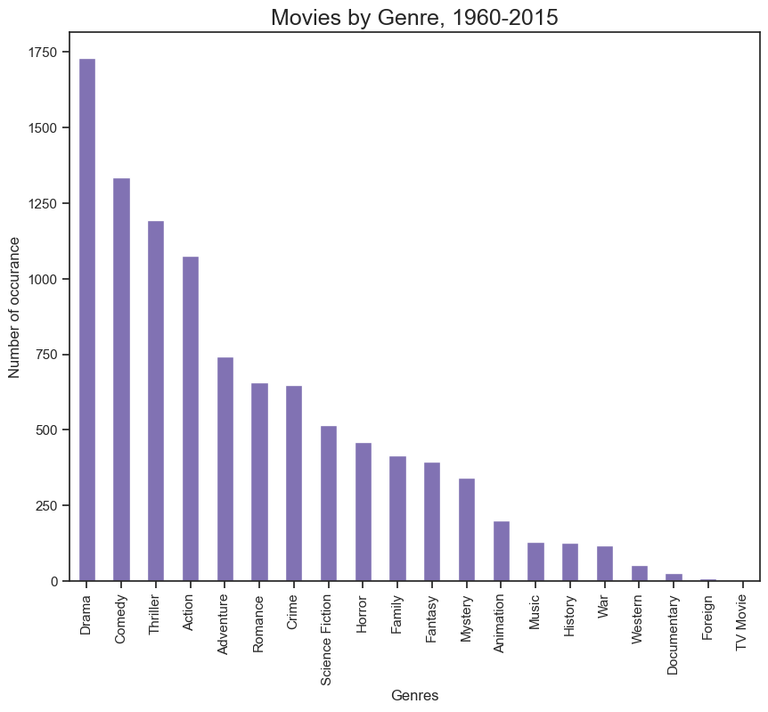

```python
df_split = df.assign(genres = df['genres'].str.split('|')).explode('genres')

df_split['genres'].value_counts(ascending = False).plot(kind='bar',figsize = (10,8),color='m');

plt.title('Movies by Genre, 1960-2015', size=18)
plt.xlabel('Genres', size=12)
plt.ylabel('Number of occurance')
sns.set_style("whitegrid")
```

As we can see, **Drama** movies are the most frequent movie genre. The top 5 dominant movie genres all over these years (1960 - 2015) are:

- Drama
- Comedy
- Thriller
- Action
- Adventure.

#### *2. Which genres are more profitable overall?*

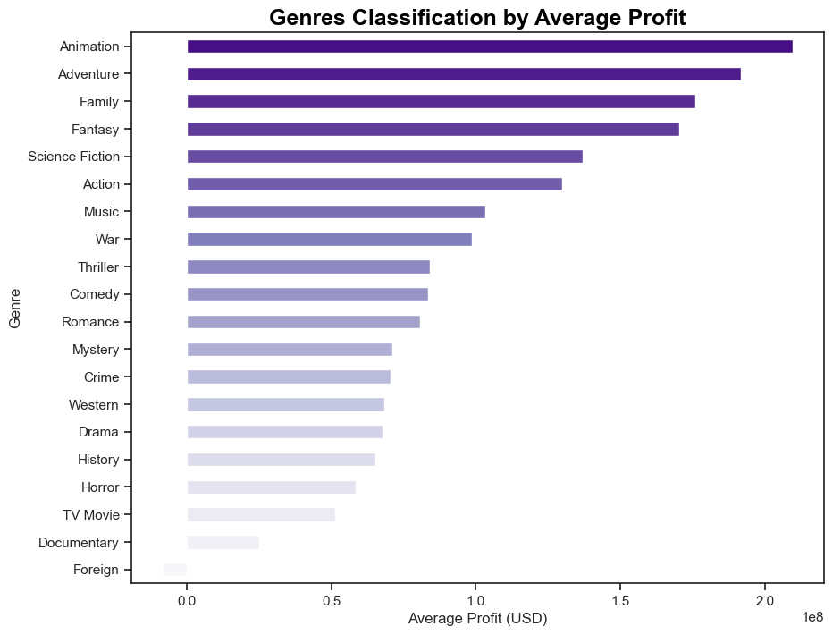

```python
df_split['profit'] = pd.to_numeric(df_split['profit'], errors='coerce')
profit_and_genres_df = df_split[['profit', 'genres']]
mean_profit_vs_genre_df = profit_and_genres_df.groupby('genres')['profit'].mean()
mean_profit_vs_genre_df = mean_profit_vs_genre_df.sort_values(ascending=False)

sns.set_style("ticks")

plt.figure(figsize=(10,8))
mean_profit_vs_genre_df.plot(
    kind='barh',
    color=sns.color_palette("Purples_r", n_colors=len(mean_profit_vs_genre_df))
)

plt.title('Genres Classification by Average Profit', fontsize=18, color='black', weight='bold')
plt.xlabel('Average Profit (USD)', fontsize=12)
plt.ylabel('Genre', fontsize=12)

plt.gca().invert_yaxis()
plt.show()
```

Even that, **"Drama"** genres are the most frequent genre produced overall, but the most profitable one is **"Animation"**. So the top 5 most profitable genres of movies from 1960 to 2015 are:

- Animation,
- Adventure,
- Family,
- Fantasy,
- Science Fiction.

#### *3. Which genres are more profitable from year to year?*

In this part, i will focus on the top 5 most profitable genres found in the last part to investigate which is the more profitable genre from year to year.

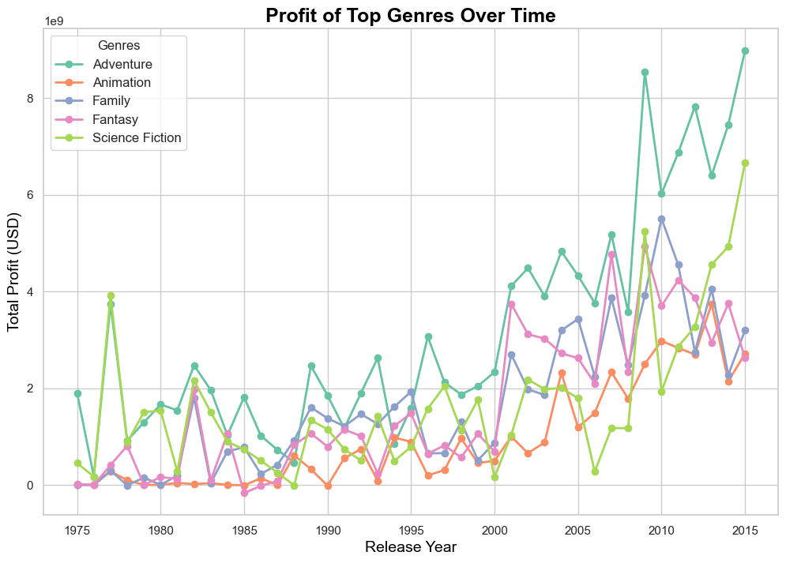

```python
df_split['profit'] = pd.to_numeric(df_split['profit'], errors='coerce')
df_split['release_year'] = pd.to_datetime(df_split['release_date'], errors='coerce').dt.year
df_split = df_split[df_split['release_year'].between(1960, 2015)]

top5_genres = ['Animation', 'Adventure', 'Family', 'Fantasy', 'Science Fiction']
df_top5 = df_split[df_split['genres'].isin(top5_genres)]
profit_top5_over_time = df_top5.groupby(['release_year','genres'])['profit'].sum().unstack().fillna(0)

sns.set_style("whitegrid")
plt.figure(figsize=(12,8))

colors = sns.color_palette("Set2", n_colors=5)
profit_top5_over_time.plot(marker='o', linewidth=2, color=colors)

plt.title('Profit of Top Genres Over Time', fontsize=18, color='black', weight='bold')
plt.xlabel('Release Year', fontsize=14, color='black')
plt.ylabel('Total Profit (USD)', fontsize=14, color='black')
plt.legend(title='Genres', fontsize=12)
plt.show()
```

Most profitable Genres varies quite a lot from year to year and have known an upward in recent years. In 2015, **Advanture** is the most profitable genre followed by **Science Fiction** in the second position and **Family** movies in the third position.

#### *4. Which genres are more popular overall?*

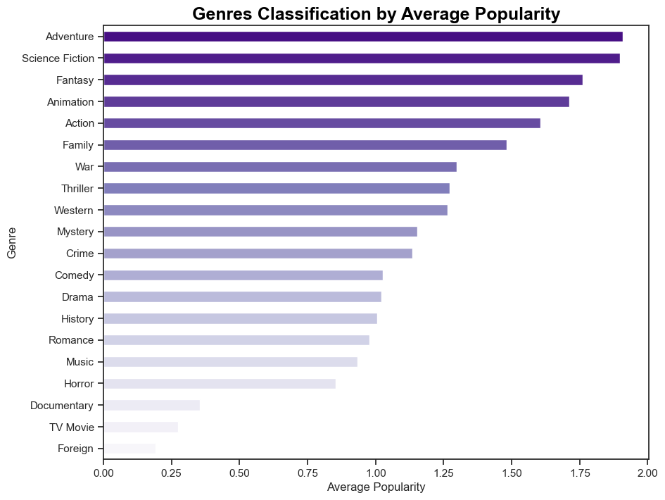

```python
df_split['popularity'] = pd.to_numeric(df_split['popularity'], errors='coerce')
popular_and_genres_df = df_split[['popularity', 'genres']]
mean_popular_vs_genre_df = popular_and_genres_df.groupby('genres')['popularity'].mean()
mean_popular_vs_genre_df = mean_popular_vs_genre_df.sort_values(ascending=False)

sns.set_style("ticks")
plt.figure(figsize=(10,8))
mean_popular_vs_genre_df.plot(
    kind='barh',
    color=sns.color_palette("Purples_r", n_colors=len(mean_popular_vs_genre_df))
)

plt.title('Genres Classification by Average Popularity', fontsize=18, color='black', weight='bold')
plt.xlabel('Average Popularity', fontsize=12)
plt.ylabel('Genre', fontsize=12)

plt.gca().invert_yaxis()
plt.show()
```

The top 5 most popular genres of movies from 1960 to 2015 are:

- Adventure,
- Science fiction,
- Fantasy,
- Animation,
- Action.

#### *5. What is the evolution of the genres according to popularity from year to year?*

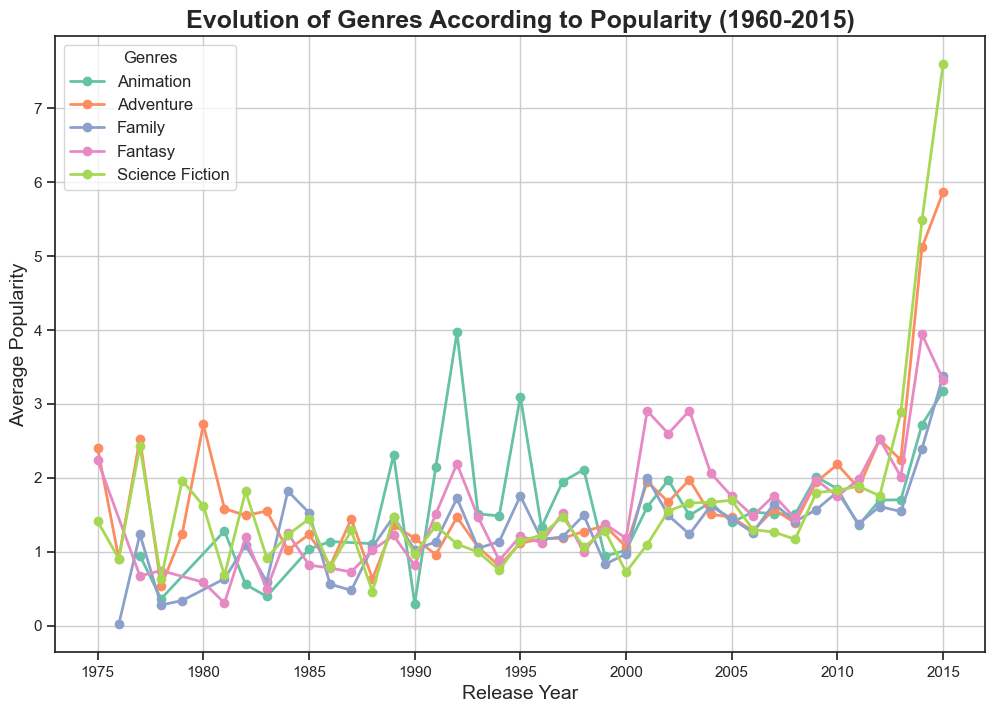

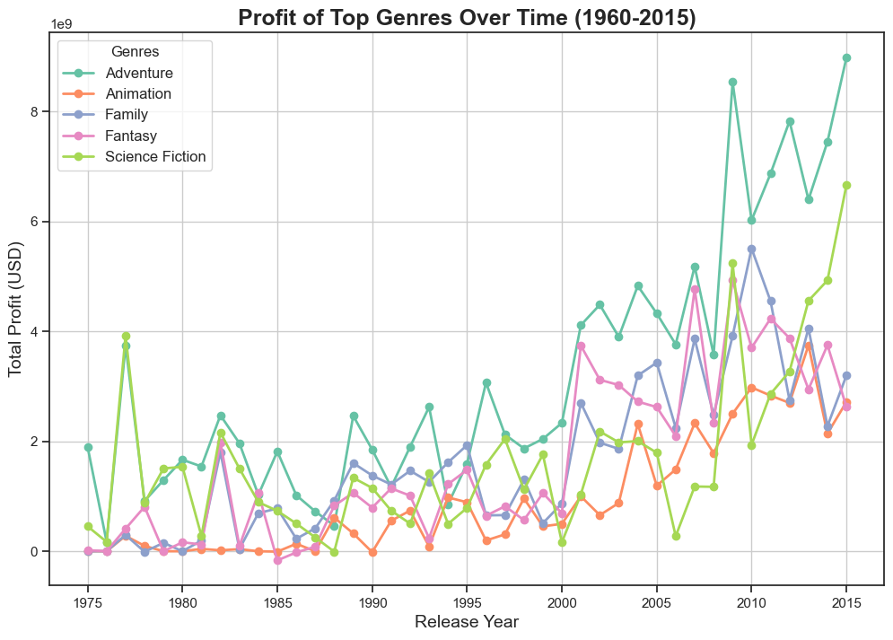

```python
df_split['profit'] = pd.to_numeric(df_split['profit'], errors='coerce')
df_split['release_year'] = pd.to_datetime(df_split['release_date'], errors='coerce').dt.year
df_split = df_split[df_split['release_year'].between(1960, 2015)]
top5_genres = ['Animation', 'Adventure', 'Family', 'Fantasy', 'Science Fiction']
df_top5 = df_split[df_split['genres'].isin(top5_genres)]

# -----------------------------
# Popularity
# -----------------------------
genre_pop_df = df_top5.groupby(['genres', 'release_year'], as_index=False)['popularity'].mean()

plt.figure(figsize=(12,8))
colors = sns.color_palette("Set2", n_colors=5)

for i, genre in enumerate(top5_genres):
    data = genre_pop_df[genre_pop_df.genres==genre]
    plt.plot(data.release_year, data.popularity, marker='o', linewidth=2, color=colors[i], label=genre)

plt.xlabel("Release Year", fontsize=14)
plt.ylabel("Average Popularity", fontsize=14)
plt.title('Evolution of Genres According to Popularity (1960-2015)', fontsize=18, weight='bold')
plt.legend(title='Genres', fontsize=12)
plt.grid(True)
plt.show()

# -----------------------------
# Profit
# -----------------------------
profit_top5_over_time = df_top5.groupby(['release_year','genres'])['profit'].sum().unstack().fillna(0)

plt.figure(figsize=(12,8))
profit_top5_over_time.plot(marker='o', linewidth=2, color=colors)

plt.title('Profit of Top Genres Over Time (1960-2015)', fontsize=18, weight='bold')
plt.xlabel('Release Year', fontsize=14)
plt.ylabel('Total Profit (USD)', fontsize=14)
plt.legend(title='Genres', fontsize=12)
plt.grid(True)
plt.show()
```

### Question 4: What are top 10 Casts, Directors and production companies?

Among the most frequently asked questions on the internet, and also the question that arises in my mind, is: who are the top 5 stars? In other words, which actors appeared most often in the movies from our dataset, and who are the top directors and production companies? I will try to answer these questions in this section.

```python
def extract_data(x):
    all_data = df[x].str.cat(sep = '|')
    all_data = pd.Series(all_data.split('|'))

    return all_data.value_counts(ascending = False)
```

```
Top 10 actors with the most apperance in movies:
```

```
Robert De Niro        52
Bruce Willis          46
Samuel L. Jackson     44
Nicolas Cage          43
Matt Damon            36
Johnny Depp           35
Harrison Ford         34
Brad Pitt             34
Sylvester Stallone    34
Tom Hanks             34
Name: count, dtype: int64
```

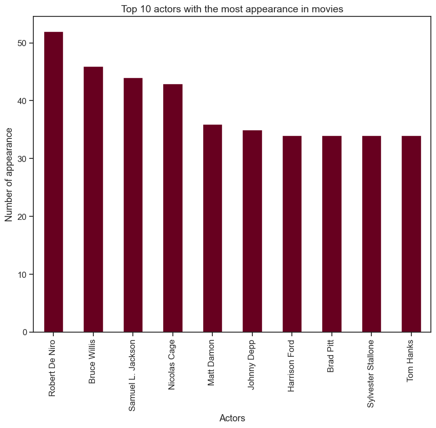

```python
top10_act=extract_data('cast').iloc[:10]
top10_act.plot.bar(figsize=(10,8),colormap= 'RdBu',fontsize=12);
plt.title("Top 10 actors with the most appearance in movies",fontsize=14)
plt.xlabel('Actors',fontsize = 13)
plt.ylabel('Number of appearance',fontsize = 13)
print('Top 10 actors with the most apperance in movies:')
top10_act
```

#### *2. Top 10 directors with high number of movies*

```
Top directors with high number of movies:
```

```
Steven Spielberg     28
Clint Eastwood       24
Ridley Scott         21
Woody Allen          18
Steven Soderbergh    17
Robert Rodriguez     17
Tim Burton           17
Martin Scorsese      17
Renny Harlin         15
Brian De Palma       15
Name: count, dtype: int64
```

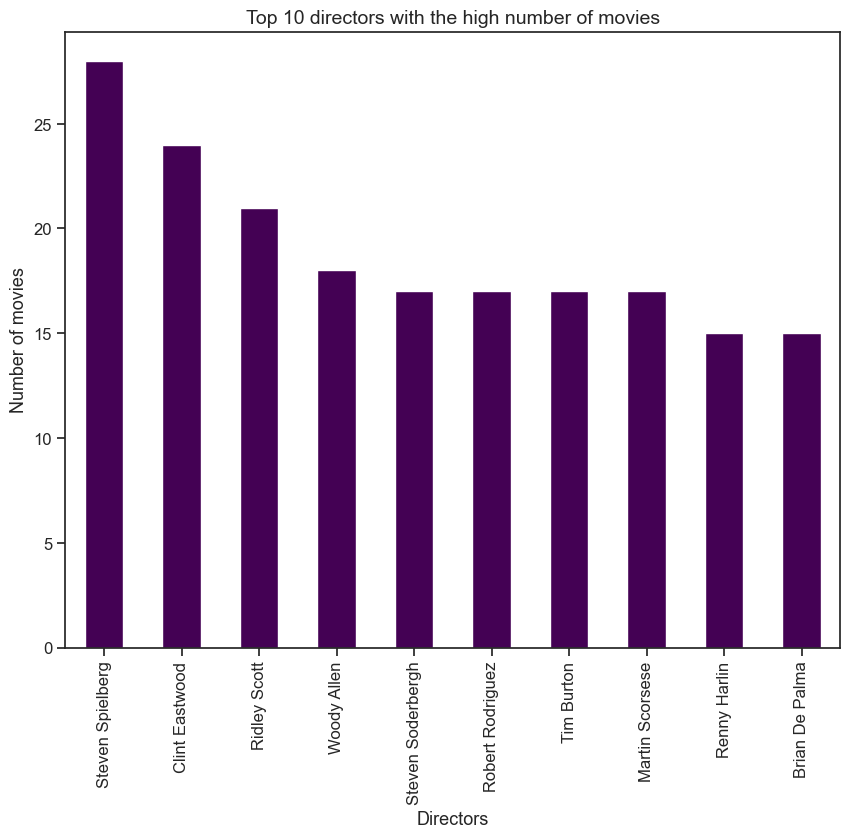

```python
top10_direct=extract_data('director').iloc[:10]
top10_direct.plot.bar(figsize=(10,8),colormap= 'viridis',fontsize=12);
plt.title("Top 10 directors with the high number of movies",fontsize=14)
plt.xlabel('Directors',fontsize = 13)
plt.ylabel('Number of movies',fontsize = 13)

print('Top directors with high number of movies:')
top10_direct
```

#### *3. Top 10 production companies with high number of movies*

```
Top 10 production companies with high nuber of movies:
```

```
Universal Pictures                        329
Warner Bros.                              324
Paramount Pictures                        270
Twentieth Century Fox Film Corporation    201
Columbia Pictures                         178
New Line Cinema                           152
Walt Disney Pictures                      117
Touchstone Pictures                       116
Metro-Goldwyn-Mayer (MGM)                 109
Relativity Media                          102
Name: count, dtype: int64
```

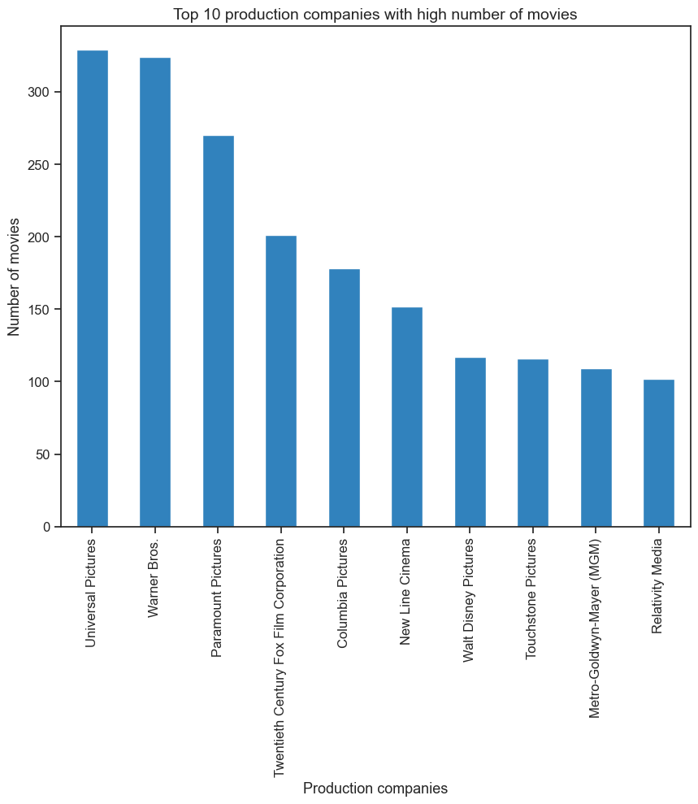

```python
top10_direct=extract_data('production_companies').iloc[:10]
extract_data('production_companies').iloc[:10].plot.bar(figsize=(10,8),colormap= 'tab20c',fontsize=12);
plt.title("Top 10 production companies with high number of movies",fontsize=14)
plt.xlabel('Production companies',fontsize = 13)
plt.ylabel('Number of movies',fontsize = 13)
print('Top 10 production companies with high nuber of movies:')
top10_direct
```

```python
!jupyter nbconvert --to html data_wrangling.ipynb
```

```
[NbConvertApp] Converting notebook data_wrangling.ipynb to html
[NbConvertApp] Writing 340344 bytes to data_wrangling.html
```